[output not shown]

# Introdução

Modelos espaciais lineares mistos generalizados são uma classe de modelos espaciais em que a resposta dos dados não é gaussiana.

Para citar referências, basta usar a sintaxe `\cite{key}` para citação indireta, ou `\citeonline{key}` para citação direta, onde `key` é a chave para a referência.

O principal resultado do projeto é obter um gráfico tão impressionante quanto aquele que está representado na Figura @ref(fig:disp). Note que, para figuras, o label do chunk vira a referência. Aqui esse label é `disp`, portanto, a referência para a figura fica `fig:disp`, e usamos `\@ref(fig:disp)`. Outra coisa importante é que, para isso funcionar, é necessário obrigatoriamente especificar uma legenda nas próprias opções do chunk, com a opção `fig.cap`.

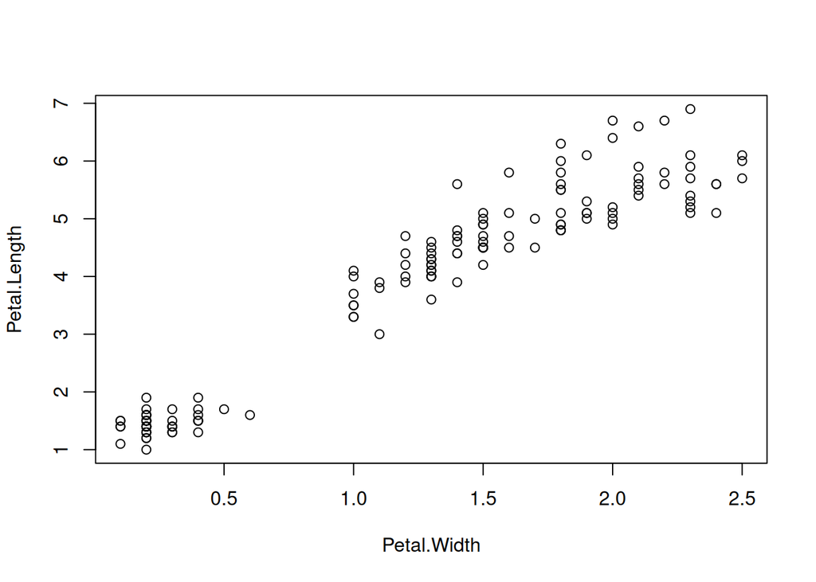

Uma legenda para esse gráfico.

Uma figura externa também pode ser incluída. Nesse caso, a melhor opção é usar a função `include_graphics()` do **knitr**, e controlar a aparência com as opções do chunk. Veja um exemplo na Figura @ref(fig:leg).

[figure not shown]

O logo do LEG.

Também é possível incluir códigos, se for necessário. Veja no próximo parágrafo como isso funciona.

Uma descrição da base de dados `iris` pode ser obtida com a função `summary()`, que faz um resumo estatístico todas as variáveis presentes em um objeto da classe `data.frame`. Veja o resultado da chamada dessa função abaixo.

```r
summary(iris)
```

```
##   Sepal.Length    Sepal.Width     Petal.Length    Petal.Width
##  Min.   :4.300   Min.   :2.000   Min.   :1.000   Min.   :0.100
##  1st Qu.:5.100   1st Qu.:2.800   1st Qu.:1.600   1st Qu.:0.300
##  Median :5.800   Median :3.000   Median :4.350   Median :1.300
##  Mean   :5.843   Mean   :3.057   Mean   :3.758   Mean   :1.199
##  3rd Qu.:6.400   3rd Qu.:3.300   3rd Qu.:5.100   3rd Qu.:1.800
##  Max.   :7.900   Max.   :4.400   Max.   :6.900   Max.   :2.500
##        Species
##  setosa    :50
##  versicolor:50
##  virginica :50
##
##
##
```

# Revisão de Literaura

Veja como fazer citações na introdução.

# Material e Métodos

## Modelos Geoestatísticos

Geoestatística refere-se ao conjunto de métodos utilizados para analisar dados que seguem a seguinte estrutura: considere o vetor de observações $y = (y_{1}, y_{2}, \ldots, y_{n})^{\top}$, coletadas nas posiçoes $x = (x_{1}, x_{2}, \ldots, x_{n})^\top$, de uma região $A$ no espaço. Tais observações foram coletadas nos pontos amostrais $x_{i}$, mas poderiam ter sido medidas em qualquer outro ponto arbitrário de $A$.

Cada observação $y$ é dada como uma realização parcial de um processo espacial contínuo não observado (latente), denotado $S(x)$, nos pontos amostrais $x_{i}$. A escolha de tais pontos pode ser aleatória, estruturada (em grades, em delineamentos amostrais, etc.) ou por conveniência.

O objetivo principal da modelagem geoestatística é recuperar esse processo latente $S(x)$, para ser possível estimar os valores nos demais pontos não amostrados, usualmente pela média do processo ($\hat{\mathbb{E}}[S(x)]$). Como esse processo não é diretamente observável, os modelos geoestatísticos são usualmente definidos como um modelo de efeitos aleatórios (mistos).

## Modelos Espaciais Lineares Mistos Generalizados

Quando as observações de um processo geoestatístico não possuem respostas gaussianas, como contagens ou proporções, usamos o seguinte modelo hierarquico para denotar o modelo espacial linear misto generalizado:

$$\begin{equation}
\begin{aligned}
[Y(x)|S(x)] &\sim f(.;\mu(x), \psi) \\
g(\mu(x)) &= D\beta + S(x)
(\#eq:modgauss)
\end{aligned}
\end{equation}$$

Assume-se que os componentes de $\textbf{Y(x)}$ são condicionalmente independentes dado o processo latente $\textbf{S(x) = \sigma U(x;\phi) + \tau Z}$. O preditor linear do modelo é ligado à média por meio da uma função de ligação $\textbf{g}$. Os efeitos fixos são denotados por **$D\beta$**, onde **$D$** representa a matriz $n \times p$ de delineamento do experimento, contendo $p$ covariáveis, e **$\beta$** um vetor $p \times 1$ de parâmetros de regressão a serem estimados.

Os efeitos aleatórios espacialmente correlacionados são dados por **$\sigma U(x;\phi)$**, onde **$\sigma$** (*sill*) denota a variância dos efeitos aleatórios e **$U(x;\phi)$** é a variância unitária de um Campo Gaussiano Aleatório (*Gaussian Random Field*), com função de correlação $\rho(u,\phi)$

## Material

| Sepal.Length | Sepal.Width | Petal.Length | Petal.Width | Species |
| --- | --- | --- | --- | --- |
| 5.1 | 3.5 | 1.4 | 0.2 | setosa |
| 4.9 | 3.0 | 1.4 | 0.2 | setosa |
| 4.7 | 3.2 | 1.3 | 0.2 | setosa |
| 4.6 | 3.1 | 1.5 | 0.2 | setosa |
| 5.0 | 3.6 | 1.4 | 0.2 | setosa |
| 5.4 | 3.9 | 1.7 | 0.4 | setosa |

Evite dizer que uma tabela está “abaixo” ou “acima”. Aqui, por exemplo, a tabela está abaixo do parágrafo, mas no documento compilado ela aparece depois de outro parágrafo.

## Métodos

$$\begin{equation*}
P(X = x) = \frac{e^{-\lambda} \lambda^x}{x!},
\quad x = 0, 1, 2, \ldots .
\end{equation*}$$

As equações também podem ser referenciadas no texto, bastando adicionar um label no formato `(\#eq:binom)`, como por exemplo

$$\begin{equation}
f\left(k\right) = \binom{n}{k} p^k\left(1-p\right)^{n-k}.
(\#eq:binom)
\end{equation}$$

Para referenciar a equação @ref(eq:binom), use `\@ref(eq:binom)`.

Existem várias opções de ambientes, inclusive para definições, teoremas e provas. Veja a página do Bookdown[^1].

# Resultados e Discussão

# Considerações Finais

[^1]: https://bookdown.org/yihui/bookdown/markdown-extensions-by-bookdown.html#equations